# Two-way ANOVA

Emma Rand

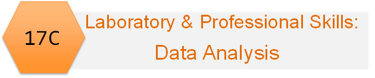

[figure not shown]

Emma Rand. (2022). Data Analysis in R (BIO00017C) 2020: 2022 (v1.1). Zenodo. https://doi.org/10.5281/zenodo.6359475

# Introduction

## Session overview

In this workshop you will get practice in applying, interpreting and reporting two-way ANOVA including the interaction term and post-hoc testing

## Learning Outcomes

By actively following the materials and carrying out the independent study before and after the contact hours the successful student will be able to:

- List the sheets in, and read data from, Excel files (MLO 3)
- Combine dataframes of the same structure (MLO 3)
- Select, appropriately two-way ANOVA (MLO 2)
- Understand the meaning of the interaction term
- Apply and interpret the two-way ANOVA (including the interaction), and post-hoc tests in R (MLO 3 and 4)
- Evaluate whether the assumptions of the test are met (MLO 2)
- Summarise and illustrate with appropriate R figures test results scientifically (MLO 3 and 4)

## Philosophy

Workshops are not a test. It is expected that you often don’t know how to start, make a lot of mistakes and need help. Do not be put off and don’t let what you can not do interfere with what you can do. You will benefit from collaborating with others and/or discussing your results. It is expected that you are familiar with independent study content before the workshop. However, you need not remember or understand every detail as the workshop should build and consolidate your understanding. You may wish to refer to the independent study materials for reference.

Materials are indexed here: https://3mmarand.github.io/BIO00017C-Data-Analysis-in-R-2020/

## Key

These four symbols are used at the beginning of each instruction so you know where to carry out the instruction.

is something you need to do on your computer. It may be opening programs or documents or locating a file.

is something you should do in RStudio. It will often be typing a command or using the menus but might also be creating folders, locating or moving files.

is something you should do in your browser on the internet. It may be searching for information, going to the VLE or downloading a file.

is question for you to think about an answer. You will usually want to record your answers in your script for future reference.

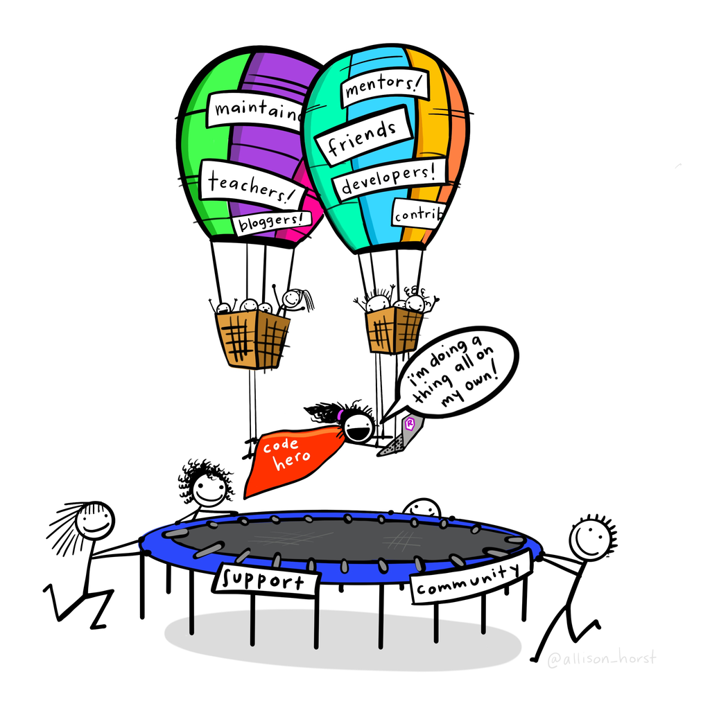

Artwork by Allison Horst

# Getting started

Start RStudio from the Start menu.

Make an RStudio project for this workshop by clicking on the drop-down menu on top right where it says Project: (None) and choosing New Project and then New Directory, then New Project. Navigate to the “data-analysis-in-r” folder. Name the RStudio Project ‘workshop6’.

On the Files tab make three folders `data-raw`, `data-processed` and `figures`

Make a new script then save it with a name like analysis.R to carry out the rest of the work.

Load the `tidyverse`:

```r
library(tidyverse)
```

# Exercises

## Parasites on two species of periwinkle

This example is about the effect of season on the parasite load of two species of periwinkle.

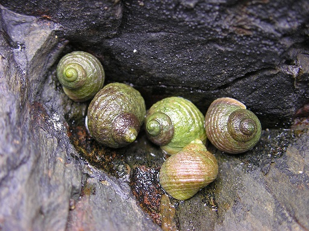

photo of periwinkles

A group of amateur conchologists have collected live specimens of two species of rough periwinkle (intertidal, gastropod molluscs) from sites in northern England in the Spring (1) and Summer (2). Among other variables, they take a measure of the gut parasite load. Number of parasites is related to the number of parasites seen on a slide of gut contents and larger numbers indicate a higher parasite load. The data are in an Excel file called periwinkle.xlsx.

There’s a good package for reading in Excel files, `readxl`. It is one of the [tidyverse](https://www.tidyverse.org/) packages and will be installed when you install `tidyverse` but it is not one of the core packages that get loaded with `library(tidyverse)` therefore we need to library it. I recommend putting all your library statements together at the top of the file.

Load `readxl` with a library statement

Save a copy of periwinkle.xlsx to your `data-raw` folder.

Open the file in Excel so you have an understanding of its contents.

The Excel file has two worksheets, one for the Spring data and one for the Summer data. We will need to import these individually and then combine the dataframes.

Assign the file path to a variable called `file`:

```r
file <- "data-raw/periwinkle.xlsx"
```

We are doing this because we will use the file path three times.

**Top Tip**

Setting the file path to a variable is useful when you need to use the path several times. If you later want to apply the same process for another analysis you only need edit the one reference to the file.

`readxl` has a useful function, `excel_sheets()` for listing the sheets in an Excel workbook.

List the sheets in the workbook:

```r
excel_sheets(file)
```

```
## [1] "spring" "summer"
```

Now we can read in the file using one of the functions from `readxl`. Look it up in the manual `?read_excel`

Import the data for Spring and examine its structure:

```r
spr <- read_excel(file, sheet = "spring")
str(spr)
```

```
## tibble [50 x 3] (S3: tbl_df/tbl/data.frame)
##  $ para   : num [1:50] 58 51 54 39 65 67 60 54 47 66 ...
##  $ season : chr [1:50] "Spring" "Spring" "Spring" "Spring" ...
##  $ species: chr [1:50] "Littorina saxatilis" "Littorina saxatilis" "Littorina saxatilis" "Littorina saxatilis" ...
```

Now import the summer data.

The `tidyverse` package `dplyr` has a function called `bind_rows()` that will bind together two dataframes that have the same columns.

Bind the two dataframes:

```r
periwinkle <- bind_rows(spr, sum)
```

Examine the structure of the resulting dataframe. You can use `str()`, or another useful function is `glimpse()`

```
## Rows: 100
## Columns: 3
## $ para    <dbl> 58, 51, 54, 39, 65, 67, 60, 54, 47, 66, 51, 43, 62, 55, 58, 43~
## $ season  <chr> "Spring", "Spring", "Spring", "Spring", "Spring", "Spring", "S~
## $ species <chr> "Littorina saxatilis", "Littorina saxatilis", "Littorina saxat~
```

It’s often a good idea to save a copy of your processed and now analysis-ready data and this is particularly useful if you had to do a lot of restructuring or combining to get your data in to a analysable state. We write dataframes to files using `write_delim()`

Write the dataframe to a plain text format file in your `data-processed` folder:

```r
write_delim(periwinkle, "data-processed/periwinkle.txt")
```

### Exploring

What type of variable is ‘para’? What are the implications for the test?

Do a quick plot of the data. We have two explanatory variables so whilst one can be mapped to the *x*-axis as was the case for *t*-test and one-way ANOVA scenarios, the other needs to be mapped to the ‘colour’ or ‘fill’ aesthetics.

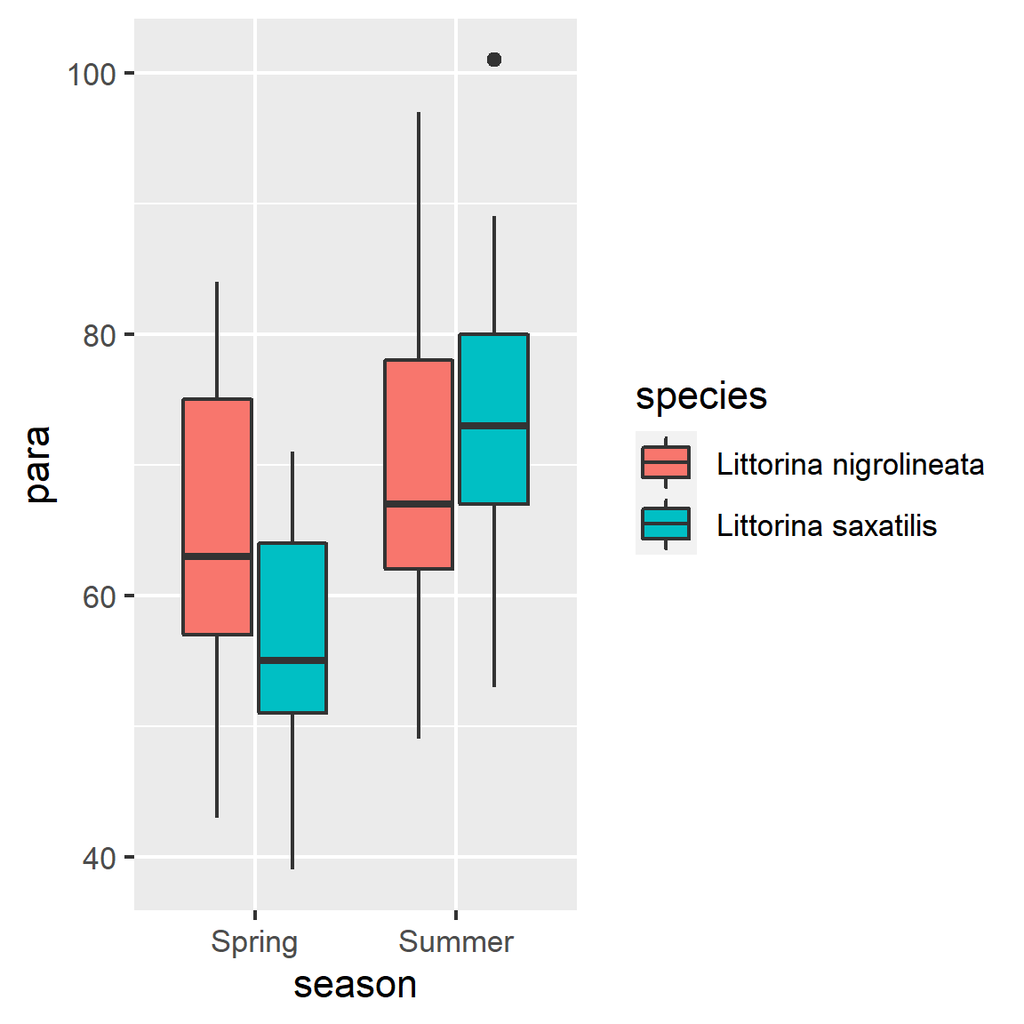

```r
ggplot(data = periwinkle, aes(x = season, y = para, fill = species)) +
  geom_boxplot()
```

I often use boxplots for exploratory plots. However, they are not appropriate to accompany parametric tests because they do not show the means and standard errors on which these tests are based.

You’ve calculated summary statistics on a response for a single explanatory several times before. Adding an additional explanatory variable is straightforward with the `group_by()` function. We just add the additional variable to the function.

Calculate summary statistics on parasite for each species-season combination:

```r
perisum <- periwinkle %>%
  group_by(season, species) %>%
  summarise(mean = mean(para),
            median = median(para),
            sd = sd(para),
            n = length(para),
            se = sd / sqrt(n))
```

Make sure you have assigned the output as you will need it later for plotting.

Our plotting and summarising exploration gives us an idea of what we expect to find on statistical analysis.

What three effects can we test with these data using a two-way ANOVA?

### Applying, interpreting and reporting

We now carry out a two-way ANOVA assigning the result of the `aov()` procedure to a variable and examining it with `summary()`. We put a `*` between the explanatory variables to indicate we want to consider both factors AND the interaction.

Create the ANOVA model with both main effects and the interaction:

```r
mod <- aov(data = periwinkle, para ~ season * species)
summary(mod)
```

```
##                Df Sum Sq Mean Sq F value   Pr(>F)
## season          1   3058  3058.1  25.580 2.03e-06 ***
## species         1     90    90.2   0.755   0.3871
## season:species  1    724   723.6   6.053   0.0157 *
## Residuals      96  11477   119.6
## ---
## Signif. codes:  0 '***' 0.001 '**' 0.01 '*' 0.05 '.' 0.1 ' ' 1
```

What do you conclude so far from the test?

We have significant effects but which means differ? We need a post-hoc test. A post-hoc (“after this”) test is done after (and only after) a significant ANOVA test. The ANOVA tells you at least two of means differ, the post-hoc test tells you where the differences are. We can use the `TukeyHSD()` in the same way as we used in for the one-way ANOVA (you may want to look back).

Carry out a Tukey HSD.

```
##   Tukey multiple comparisons of means
##     95% family-wise confidence level
##
## Fit: aov(formula = para ~ season * species, data = periwinkle)
##
## $season
##                diff      lwr      upr p adj
## Summer-Spring 11.06 6.719279 15.40072 2e-06
##
## $species
##                                            diff       lwr      upr     p adj
## Littorina saxatilis-Littorina nigrolineata -1.9 -6.240721 2.440721 0.3870918
##
## $`season:species`
##                                                               diff        lwr
## Summer:Littorina nigrolineata-Spring:Littorina nigrolineata   5.68  -2.405859
## Spring:Littorina saxatilis-Spring:Littorina nigrolineata     -7.28 -15.365859
## Summer:Littorina saxatilis-Spring:Littorina nigrolineata      9.16   1.074141
## Spring:Littorina saxatilis-Summer:Littorina nigrolineata    -12.96 -21.045859
## Summer:Littorina saxatilis-Summer:Littorina nigrolineata      3.48  -4.605859
## Summer:Littorina saxatilis-Spring:Littorina saxatilis        16.44   8.354141
##                                                                   upr     p adj
## Summer:Littorina nigrolineata-Spring:Littorina nigrolineata 13.765859 0.2626986
## Spring:Littorina saxatilis-Spring:Littorina nigrolineata     0.805859 0.0932018
## Summer:Littorina saxatilis-Spring:Littorina nigrolineata    17.245859 0.0198124
## Spring:Littorina saxatilis-Summer:Littorina nigrolineata    -4.874141 0.0003558
## Summer:Littorina saxatilis-Summer:Littorina nigrolineata    11.565859 0.6749008
## Summer:Littorina saxatilis-Spring:Littorina saxatilis       24.525859 0.0000041
```

Note that long names for group combinations means that the output wraps. You may want to increase the size of your console window to see to output unwrapped.

We have three bits of output, eaching corresponding to the three null hypotheses. There is a significant difference between the season with a difference between the means of 11.1 parasites. We then have significant comparisons between: Spring and Summer for *L. saxatilis*; *L.nigrolineata* in the Summer and *L.saxatilis* in the Spring; *L.nigrolineata* in Spring and *L.saxatilis* in Summer.

### Checking selection

Check the assumptions of the test by looking at the distribution of the ‘residuals’. You may want to look at last week’s script.

What do you conclude about the test assumptions?

### Illustrating

Producing a figure to go with this result using `ggplot2`. We will again need the means and standard errors calculated earlier and stored in `perisum`

We are going to create a figure like this:

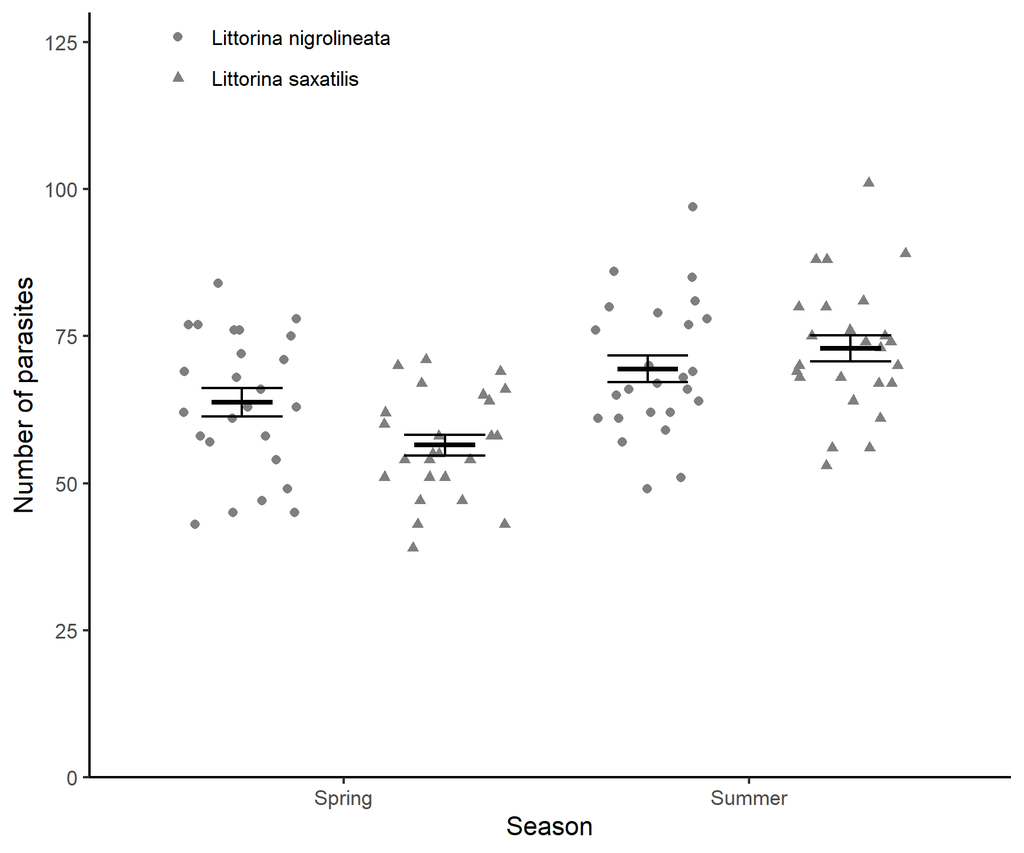

Figure 1. The effect of season on the parasite load in two species of periwinkle. Thick lines give the means and error bars are $\pm$ 1 S.E.

We will plot the means and error bars. Look this up in the Oneway ANOVA workshop.

Let’s try doing the same here:

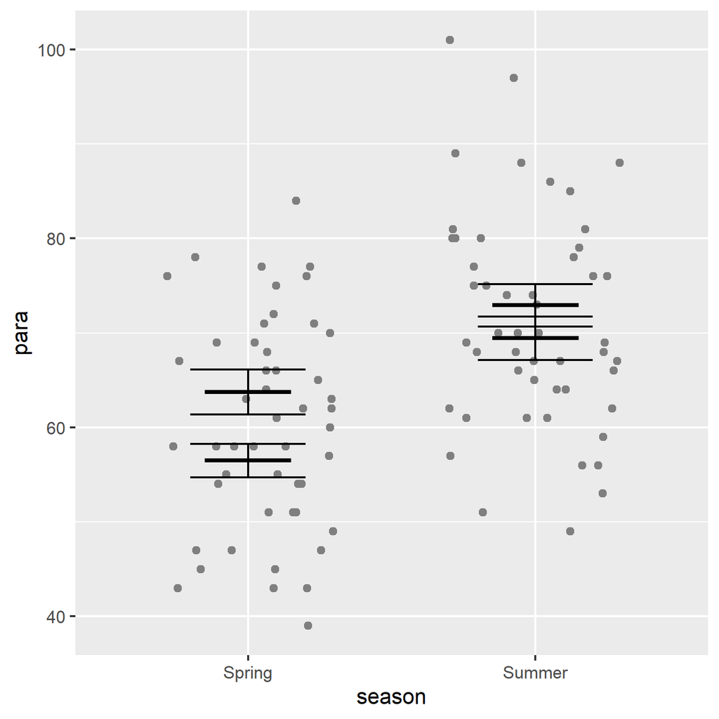

```r
ggplot() +
  geom_point(data = periwinkle,
             aes(x = season, y = para),
             position = position_jitter(width = 0.3,
                                        height = 0),
             colour = "gray50") +
  geom_errorbar(data = perisum,
                aes(x = season,
                    ymin = mean - se,
                    ymax = mean + se),
                width = 0.4,
                position = position_dodge(width = 1)) +
  geom_errorbar(data = perisum,
                aes(x = season,
                    ymin = mean,
                    ymax = mean),
                width = 0.3,
                size = 1)
```

How can we show the species separately?

We can map the species variable to the shape aesthetic!

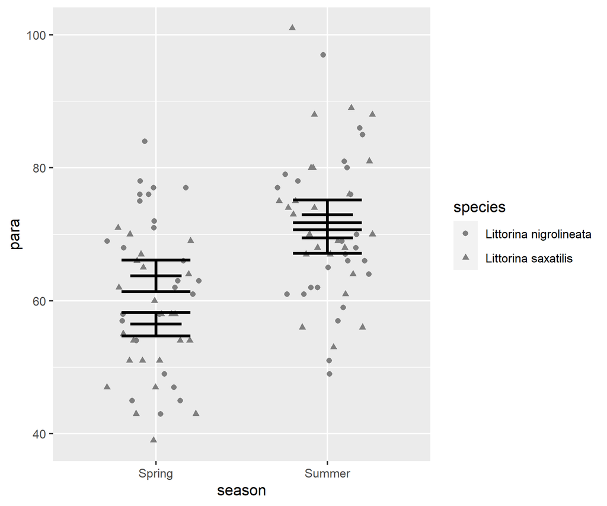

```r
ggplot() +
  geom_point(data = periwinkle,
             aes(x = season, y = para, shape = species),
             position = position_jitter(width = 0.3,
                                        height = 0),
             colour = "gray50") +
  geom_errorbar(data = perisum,
                aes(x = season,
                    ymin = mean - se,
                    ymax = mean + se),
                width = 0.4, size = 1) +
  geom_errorbar(data = perisum,
                aes(x = season,
                    ymin = mean,
                    ymax = mean),
                width = 0.3,
                size = 1)
```

Oh, that isn’t quite what we want! We want the species side-by-side, not on top of each other.

We can achieve that by using setting the `position` argument to `position_jitterdodge()` in the `geom_point()` and to `position_dodge()` in the two `geom_errorbar()`. We also have to specify that the error bars are grouped by species since they are not otherwise mapped to a shape, colour or fill.

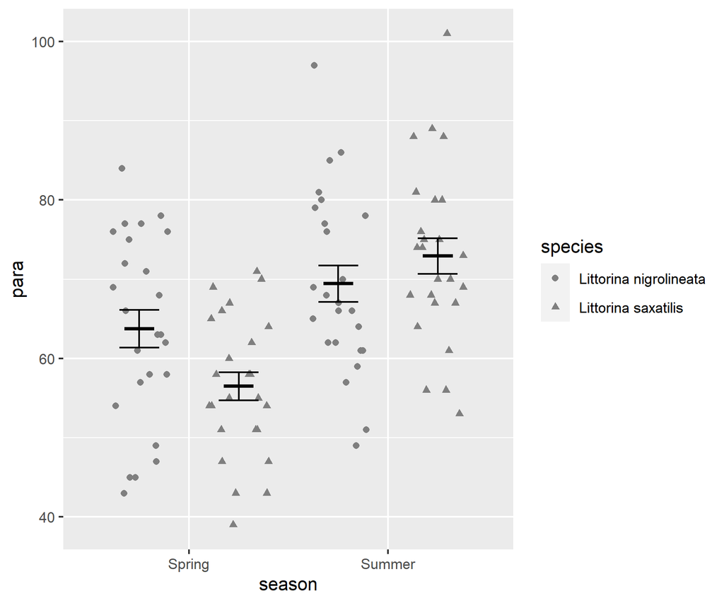

```r
ggplot() +
  geom_point(data = periwinkle,
             aes(x = season, y = para, shape = species),
             position = position_jitterdodge(dodge.width = 1,
                                             jitter.width = 0.3,
                                             jitter.height = 0),
             colour = "gray50") +
  geom_errorbar(data = perisum,
                aes(x = season,
                    ymin = mean - se,
                    ymax = mean + se,
                    group = species),
                width = 0.4,
                position = position_dodge(width = 1)) +
  geom_errorbar(data = perisum,
                aes(x = season,
                    ymin = mean,
                    ymax = mean,
                    group = species),
                width = 0.3,
                size = 1,
                position = position_dodge(width = 1) )
```

Finally we add axis labels, specify the *y*-axis limits and add `theme_classic()`. I’ve also altered the legend position and got rid of the legend title.

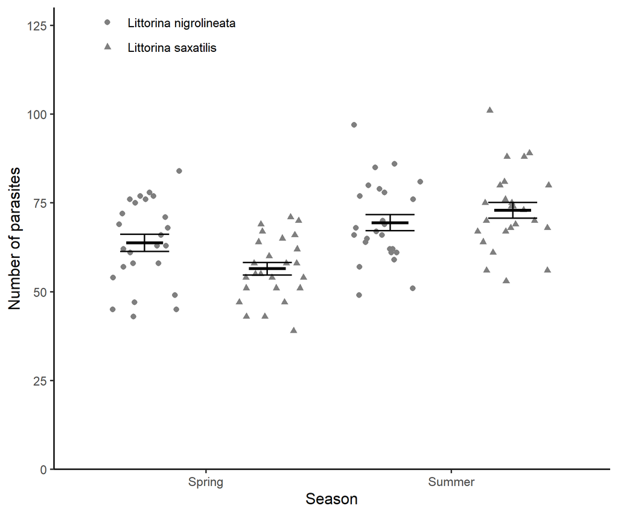

```r
ggplot() +
  geom_point(data = periwinkle,
             aes(x = season, y = para, shape = species),
             position = position_jitterdodge(dodge.width = 1,
                                             jitter.width = 0.3,
                                             jitter.height = 0),
             colour = "gray50") +
  geom_errorbar(data = perisum,
                aes(x = season,
                    ymin = mean - se,
                    ymax = mean + se,
                    group = species),
                width = 0.4,
                position = position_dodge(width = 1)) +
  geom_errorbar(data = perisum,
                aes(x = season,
                    ymin = mean,
                    ymax = mean,
                    group = species),
                width = 0.3,
                size = 1,
                position = position_dodge(width = 1) ) +
  scale_y_continuous(name = "Number of parasites",
                     expand = c(0, 0),
                     limits = c(0, 130)) +
  scale_x_discrete(name = "Season") +
  theme_classic() +
  theme(legend.title = element_blank(),
        legend.position = c(0.2, 0.95))
```

We are nearly there!

Now you add the annotation for the post-hoc result. You may want to look up last week’s workshop.

Use `ggsave()` to save your figure to the `figures` folder

# Independent study following the workshop

## 1. Fertilising a crop with Nitrogen and Potassium

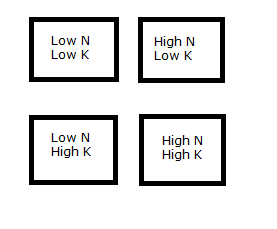

# The Code files

These contain all the code needed in the workshop even where it is not visible on the webpage.

Rmd file The Rmd file is the file I use to compile the practical. Rmd stands for R markdown. It allows R code and ordinary text to be interweaved to produce well-formatted reports including webpages. If you right-click on the link and choose Save-As, you will be able to open the Rmd file in RStudio. Alternatively, [View in Browser](https://github.com/3mmaRand/BIO00017C-Data-Analysis-in-R-2020/blob/main/workshops/06Two-wayAnova.Rmd).

Plain script file This is plain script (.R) version of the practical generated from the Rmd. Again, you can save this and open it RStudio. Alternatively, [View in Browser](https://github.com/3mmaRand/BIO00017C-Data-Analysis-in-R-2020/blob/main/scripts/06Two-wayAnova.R).

Pages made with `rmarkdown` (Allaire Xie, et al., 2019a; Xie Allaire, et al., 2018a), `kableExtra` (Zhu, 2019a), `RefManager` (McLean, 2014)

# References

Allaire, J., Y. Xie, et al. (2019a). *rmarkdown: Dynamic Documents for R*. R package version 1.16. URL: https://github.com/rstudio/rmarkdown.

McLean, M. W. (2014). *Straightforward Bibliography Management in R Using the RefManager Package*. arXiv: 1403.2036 [cs.DL]. URL: https://arxiv.org/abs/1403.2036.

Xie, Y., J. Allaire, et al. (2018a). *R Markdown: The Definitive Guide*. ISBN 9781138359338. Boca Raton, Florida: Chapman and Hall/CRC. URL: https://bookdown.org/yihui/rmarkdown.

Zhu, H. (2019a). *kableExtra: Construct Complex Table with ‘kable’ and Pipe Syntax*. R package version 1.1.0. URL: https://CRAN.R-project.org/package=kableExtra.

# Please cite as:

Emma Rand. (2022). Data Analysis in R (BIO00017C) 2020: 2022 (v1.1). Zenodo. https://doi.org/10.5281/zenodo.6359475

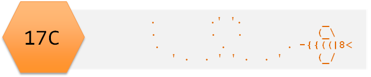